# User Guide

## Introduction

PhenEndo provides a framework for high-dimensional longitudinal clustering for studying endotypes targeted for questionnaire or other biomedical records. To make you confident with this functionality, we will walk you through the whole process by showing you a small example with our custom dataset. It can be downloaded here. The dataset contains 192 attributes of mixed type, i.e. categorical, numerical and ordered. To specify the features datatype, we also provide a second file, containing a name list of all attributes and their data types.

## Upload Data

We recommend the user to upload two data files.

1. The first one contains the attributes (or features) which are going to be analyzed for every biomedical record. The last two columns are the patient id and visit number. Every row corresponds to one hospital visit of a single patient.
2. The second one annotates the data type of all features in the dataset.

Phenendo accepts .csv, .txt, .xlsx data files. To get an idea of the data format, please check with our custom data.

## Dimension Reduction

Dimension reduction of the provided dataset is a key element of the further cluster analysis. The features are grouped by the user and on each group FAMD is applied. Each grouping of attributes is represented by principle components, whose number is specified by the user. For this reason, an extra file should be provided, which contains a pairings of attribute and a correponding group. An example can be seen here.

### Loadings Table

In our example, the groupings are represented by one principle component each. For each group the feature loadings are provided, e.g. for group 3 we get:

| ymrs_itm1 | ymrs_itm10 | ymrs_itm11 | ymrs_itm2 | ymrs_itm3 | ymrs_itm4 | ymrs_itm5 | ymrs_itm6 | ymrs_itm7 | ymrs_itm8 | ymrs_itm9 |
| --- | --- | --- | --- | --- | --- | --- | --- | --- | --- | --- |
| 0.4996348 | 0.1600985 | 0.161167 | 0.5743189 | 0.3360256 | 0.2783704 | 0.2721094 | 0.5547824 | 0.4858946 | 0.3596537 | 0.2380648 |

### Individual Factor Plot

A two dimensional representation of the individual factor scores with axes the principal components corresponding to the two highest variance scores of the groups. The user can trace the individual factor scores over all visits.

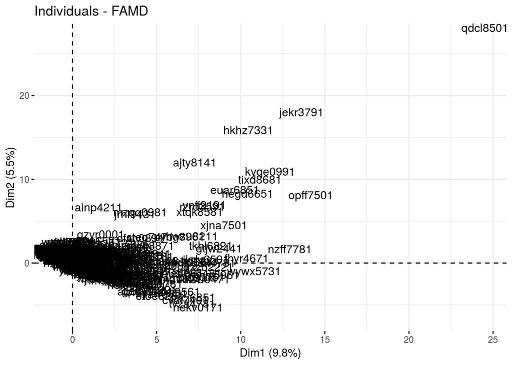

The plot shows the individual factors for the forth visit.

## Longitudinal Clustering

To cluster the longitudinal dataset we use the package flexmix. Repeatedly, it fits a mixture of generalized additive models for a different number of components (clusters). The obtained clusters are Gaussian-like.

### Cluster Selection

The fitted models range from 2 to a number given by the user. Each clustering is evaluated with respect to three measures: AIC, BIC, Integrated Classification Likelihood (ICL). In our example, BIC and ICL suggest that the optimal number of clusters is seven; the AIC score is minimized by 8 cluters.

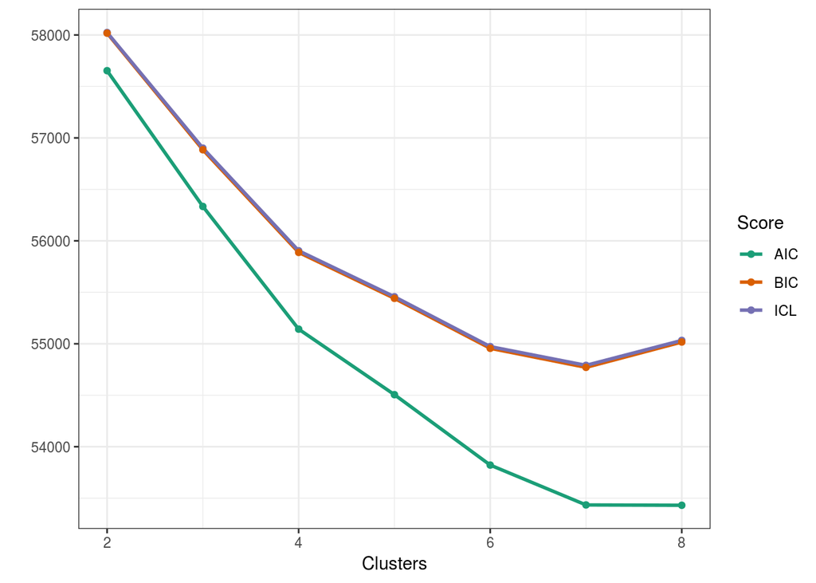

### Sankey Plot

The sankey diagram depicts the flow of the observations from one clustering to the other. Here, eight states are shown such that every state contains nodes correponding to the clusters in the data. The links between the nodes represent the data flow.

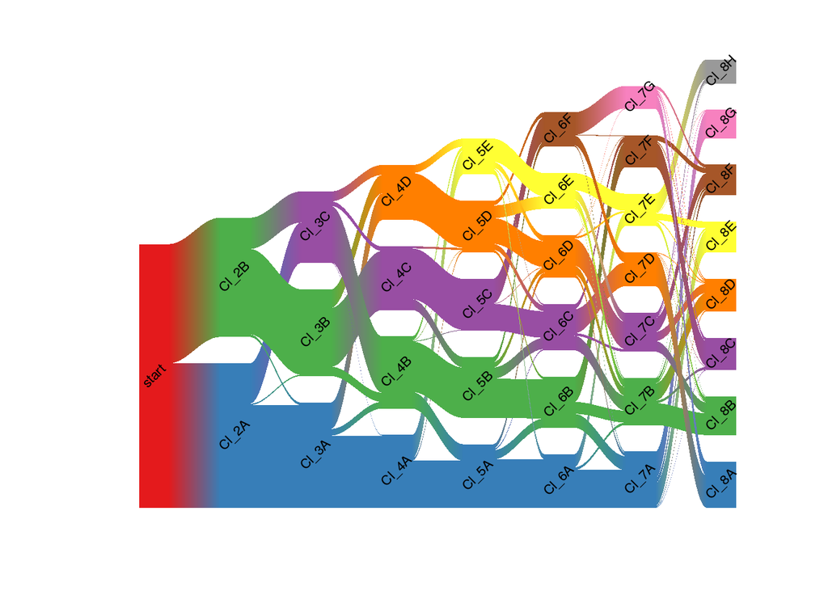

### Spaghetti Plot

Phenendo also provides a spaghetti plot for each group principle component over time. The example figure bellow is a spaghetti plot for the third group over the four visits. The clusters are denoted by the assigned letters; the thick lines show the cluster mean over time.

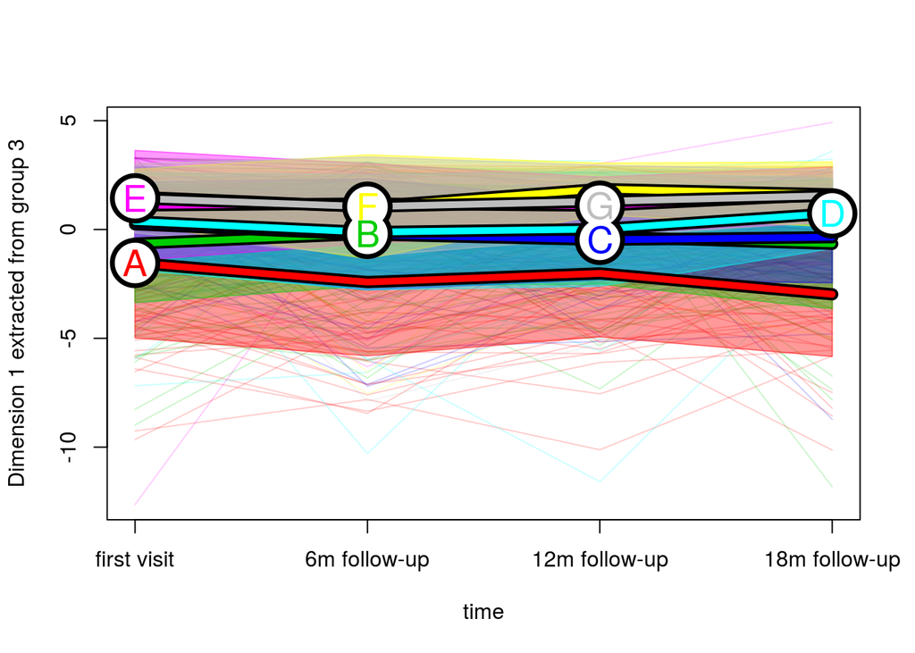